# 12-BayesMCMC.R

jfieberg

2026-03-16

# JAGS t-test/linear model

## Preamble

To install BEST package (since no longer on CRAN)

```r
#remotes::install_version("BEST", version = "0.1.0")
```

Increase width of output

```r
options(width=150)
```

Install & Load any libraries

```r
library(rjags) # for accessing JAGS
library(R2jags) # for interfacing with JAGS
#library(mcmcplots) # for plotting results (no longer on CRAN)
library(ggplot2) # for some later plotting
library(MCMCvis) # for summarizing MCMC results, other options: ggmcmc, bayesplot and basicMCMCplots
#library(BEST) # for prior / posterior overlap (no longer on CRAN)
library(dplyr) # for data wrangling
library(knitr) # for options when knitting
library(ggplot2) # for plotting
library(ggthemes) # for colorblind theme
```

Read in data

```r
males<-c(120, 107, 110, 116, 114, 111, 113, 117, 114, 112)
females<-c(110, 111, 107, 108, 110, 105, 107, 106, 111, 111)
```

JAGS/Bugs model for jaw data

```r
jaw.mod<-function(){

  # Likelihood (Y | mu) = normal(mu[sex], sigma^2)
    for(i in 1:nmales){
      males[i] ~ dnorm(mu.male, tau)
    }
    for(i in 1:nfemales){
      females[i] ~ dnorm(mu.female, tau)
    }

  # Priors
  mu.male ~ dnorm(100, 0.001) # mean of male jaw lengths
  mu.female ~ dnorm(100, 0.001) # mean of female jaw lengths
  sigma ~ dunif(0, 30) # common sigma
  tau <- 1/(sigma*sigma) #precision

  # Derived quantities:  difference in means
    mu.diff <- mu.male - mu.female
}


# Function to generate initial values
init.vals<-function(){
    mu.male <- rnorm(1, 100, 100)
    mu.female <- rnorm(1, 100, 100)
    sigma <- runif(1, 0, 10)
    out <- list(mu.male = mu.male,
                mu.female = mu.female,
                sigma = sigma)
}
```

Create rest of the data for the model

```r
nmales<-length(males)
nfemales<-length(females)
```

If spinning, add “progress.bar=”gui” or “none” to jags function (for Mac users, use the “none” option!)

```r
t.test.jags <- jags(data=c("males", "females","nmales",  "nfemales"),
                    inits=init.vals,
                    parameters.to.save=c("mu.male", "mu.female","sigma", "mu.diff"),
                    progress.bar = "none",
                    n.iter=10000,
                    n.burnin=5000,
                    n.thin=1,
                    n.chains=3,
                    model.file=jaw.mod)
```

Or, to take advantage of parallel processing

```r
t.test.jags<-jags.parallel(data=c("males", "females","nmales",  "nfemales"),
                           inits=init.vals,
                           parameters.to.save=c("mu.male", "mu.female","sigma", "mu.diff"),
                           n.iter=10000,
                           n.burnin=5000,
                           n.thin=1,
                           n.chains=3,
                           model.file=jaw.mod)
```

Look at the output

```r
t.test.jags
```

```
## Inference for Bugs model at "jaw.mod", fit using jags,
##  3 chains, each with 10000 iterations (first 5000 discarded)
##  n.sims = 15000 iterations saved. Running time = secs
##           mu.vect sd.vect    2.5%     25%     50%     75%   97.5%  Rhat n.eff
## mu.diff     4.779   1.508   1.775   3.797   4.772   5.760   7.740 1.001 15000
## mu.female 108.602   1.064 106.501 107.912 108.598 109.284 110.683 1.001 15000
## mu.male   113.381   1.069 111.262 112.688 113.375 114.082 115.511 1.001  9600
## sigma       3.317   0.594   2.380   2.895   3.239   3.655   4.701 1.002  3200
## deviance  103.075   2.744  99.892 101.036 102.395 104.379 110.156 1.001  4900
##
## For each parameter, n.eff is a crude measure of effective sample size,
## and Rhat is the potential scale reduction factor (at convergence, Rhat=1).
##
## DIC info (using the rule: pV = var(deviance)/2)
## pV = 3.8 and DIC = 106.8
## DIC is an estimate of expected predictive error (lower deviance is better).
```

```r
#" Summarize output for a subset of parameters
MCMCsummary(t.test.jags, params = c("mu.male", "mu.female"))
```

```
##               mean       sd     2.5%      50%    97.5% Rhat n.eff
## mu.male   113.3814 1.069292 111.2623 113.3752 115.5112    1 15000
## mu.female 108.6021 1.064330 106.5008 108.5981 110.6833    1 15364
```

```r
# Use MCMCsummary to pull off posterior means
bayesests <- MCMCpstr(t.test.jags, params = c("mu.male", "mu.female"), func = mean)
bayesests
```

```
## $mu.male
## [1] 113.3814
##
## $mu.female
## [1] 108.6021
```

```r
# Use MCMCsummary to pull of upper and lower 95% credible interval limits
bayesci <-  MCMCpstr(t.test.jags, params = c("mu.male", "mu.female"),
                        func = function(x) quantile(x, probs = c(0.025, 0.975)))
bayesci
```

```
## $mu.male
##             2.5%    97.5%
## mu.male 111.2623 115.5112
##
## $mu.female
##               2.5%    97.5%
## mu.female 106.5008 110.6833
```

Look at posterior density and trace plots. ind = TRUE plots all 3 chains.

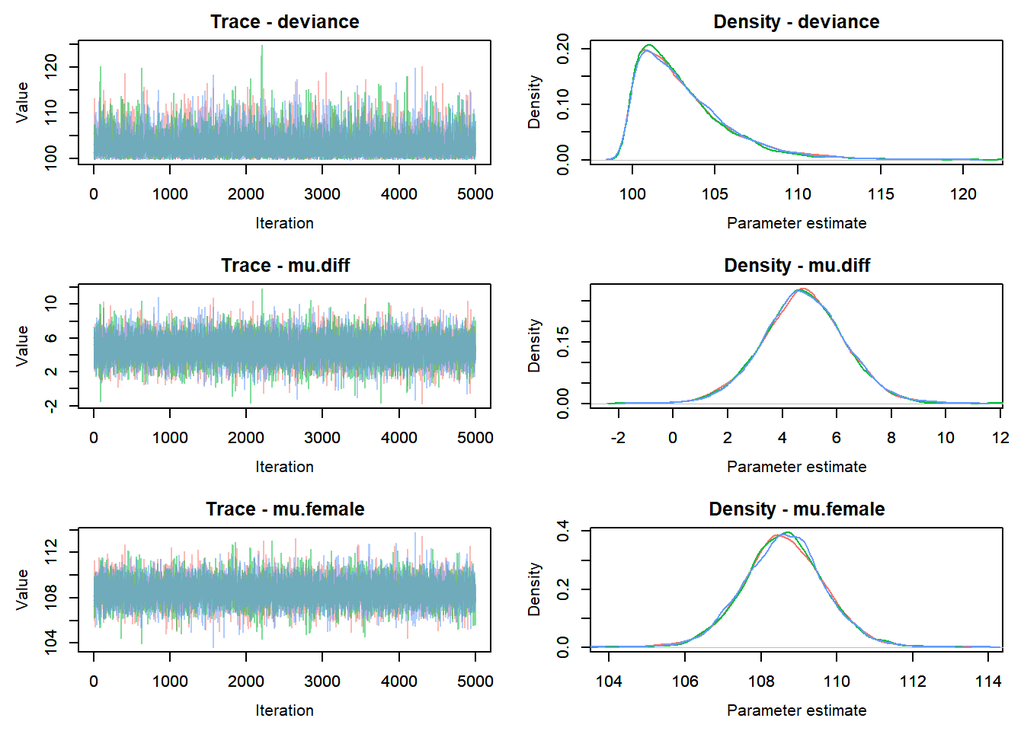

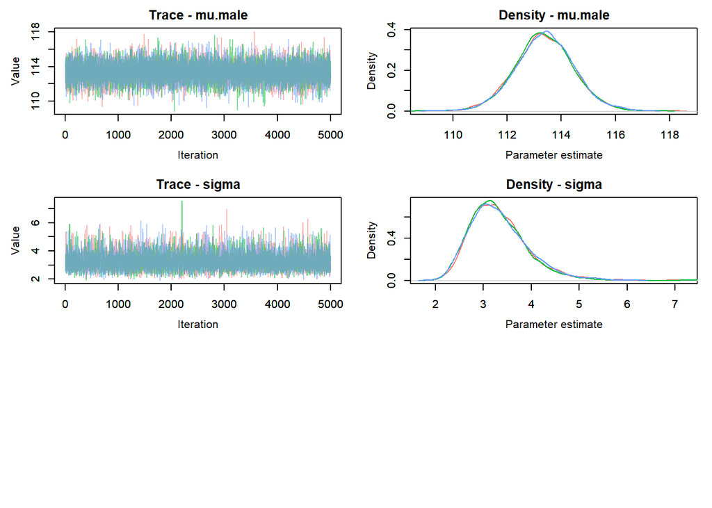

```r
MCMCtrace(t.test.jags, ind = TRUE, , pdf = FALSE)
```

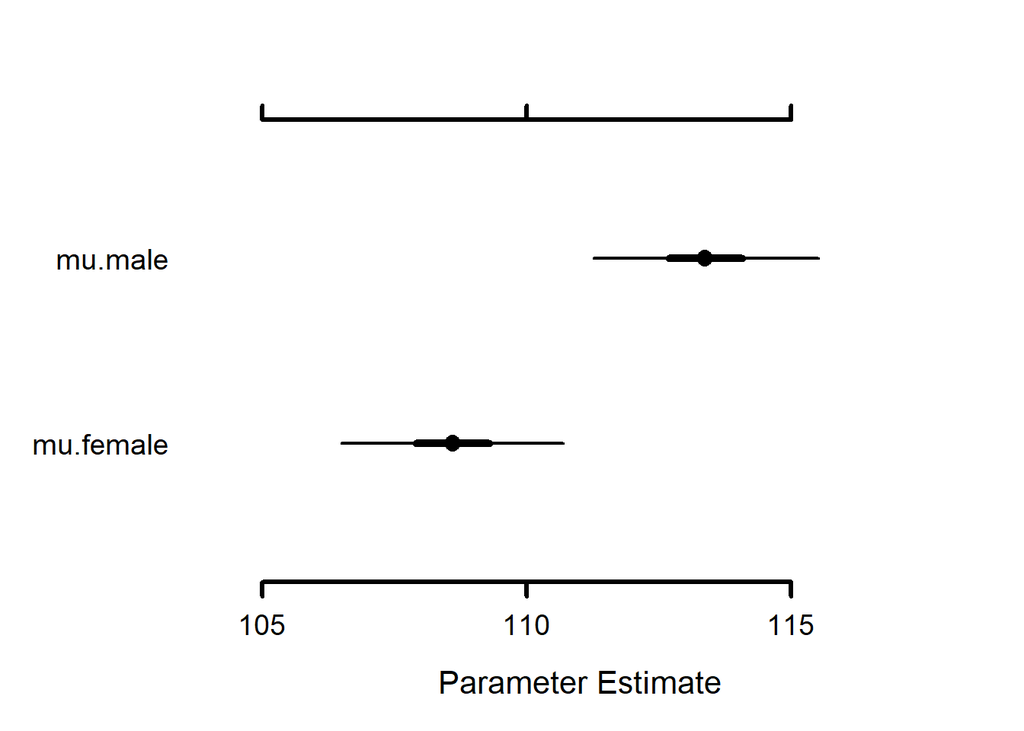

```r
MCMCplot(t.test.jags,
          params=c("mu.male", "mu.female"))
```

# Compare to linear model fit using lm

```r
# Fit linear model in frequentist framework
jawdat<-data.frame(jaws=c(males, females),
                    sex=c(rep("Male", length(males)),
                          rep("Female", length(females))))
lm.jaw<-lm(jaws~sex-1, data=jawdat)


# Store results
betaf <- coef(lm.jaw)
CIf <-confint(lm.jaw)
ests<-data.frame(estimate = c(bayesests$mu.female, bayesests$mu.male, betaf),
                 LCL = c(bayesci$mu.female[1],   bayesci$mu.male[1], CIf[,1]),
                 UCL = c(bayesci$mu.female[2],   bayesci$mu.male[2], CIf[,2]),
                 param = c("Mean females", "Mean males"),
                 Method = rep(c("Bayesian", "Frequentist"), each = 2))
```

Compare Bayesian and frequentist estimates

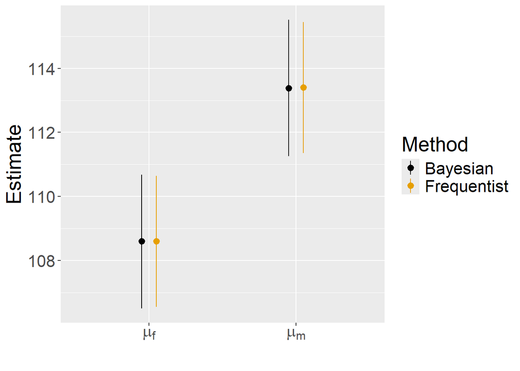

```r
ggplot(ests, aes(param,estimate, col = Method)) +
  geom_point(position = position_dodge(width = 0.2))+
  geom_pointrange(aes(ymin = LCL, ymax= UCL), position = position_dodge(width = 0.2))+
  ylab("Estimate") + xlab("") +
  scale_x_discrete(labels = c('Mean females' = expression(mu[f]),
                              'Mean males'   = expression(mu[m]))) +
  scale_colour_colorblind()+
  theme(text = element_text(size = 20))
```

For more control, we can also access the samples for the different chains using MCMCchains

```r
mus<- MCMCchains(t.test.jags, params=c("mu.male", "mu.female"))
str(mus)
```

```
##  num [1:15000, 1:2] 113 112 113 114 111 ...
##  - attr(*, "dimnames")=List of 2
##   ..$ : NULL
##   ..$ : chr [1:2] "mu.male" "mu.female"
```

```r
head(mus)
```

```
##       mu.male mu.female
## [1,] 113.0660  107.7826
## [2,] 111.7445  105.9749
## [3,] 113.3888  111.2739
## [4,] 114.2941  107.5912
## [5,] 111.3855  108.1700
## [6,] 113.9534  108.6442
```

Plot posteriors

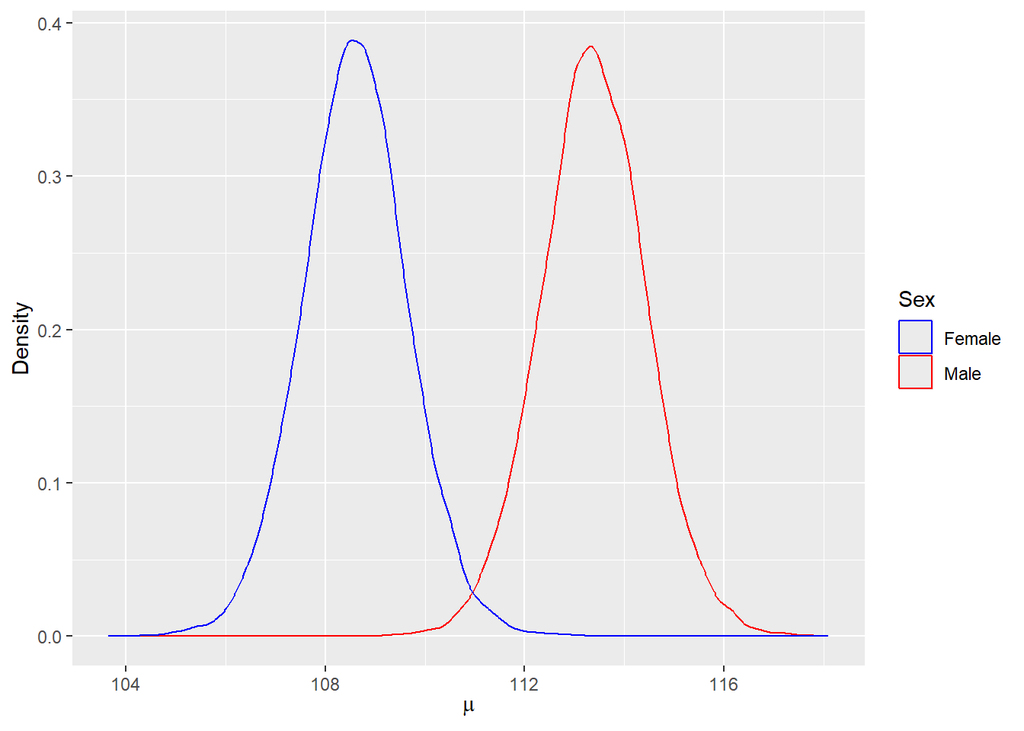

```r
ggplot(mus) +
  geom_density(aes(mu.male, col = "Male")) +
  geom_density(aes(mu.female, col = "Female")) +
  scale_color_manual(values = c("Male" = "red", "Female" = "blue")) +
  labs(color = "Sex", x = expression(mu), y = "Density")
```

Another option

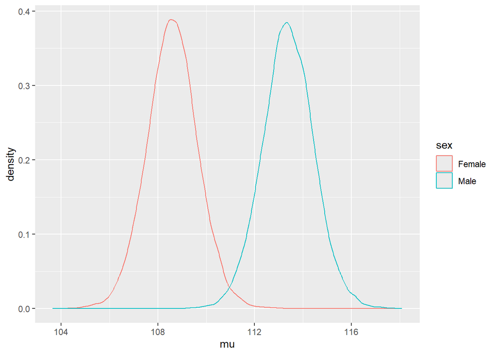

```r
musMCMC2<-data.frame(mu = c(mus[,1], mus[,2]),
                            sex=rep(c("Male", "Female"), each = 15000))
ggplot(musMCMC2, aes(mu, col=sex))+geom_density()
```

## Prior posterior overlap

We can look at prior/posterior overlap using `MCMCtrace`. This requires that we first generate samples from our priors, ordered alphabetically in a matrix. We also need the same number of iterations as captured by the posterior distribution. Generate the same number of samples from the prior distribution for sigma

```r
niters<-15000 # total number of iterations
Prior.samples<-runif(niters, 0, 30)
```

Now, call MCMCtrace

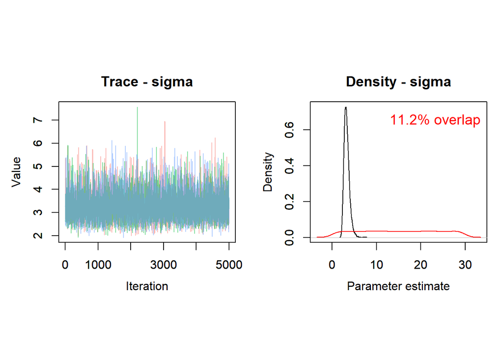

```r
MCMCtrace(t.test.jags, params = c("sigma"),
          priors = Prior.samples,
          pdf = FALSE,
          post_zm = FALSE)
```

Or, create our own plot by combining prior and posterior samples in a data frame

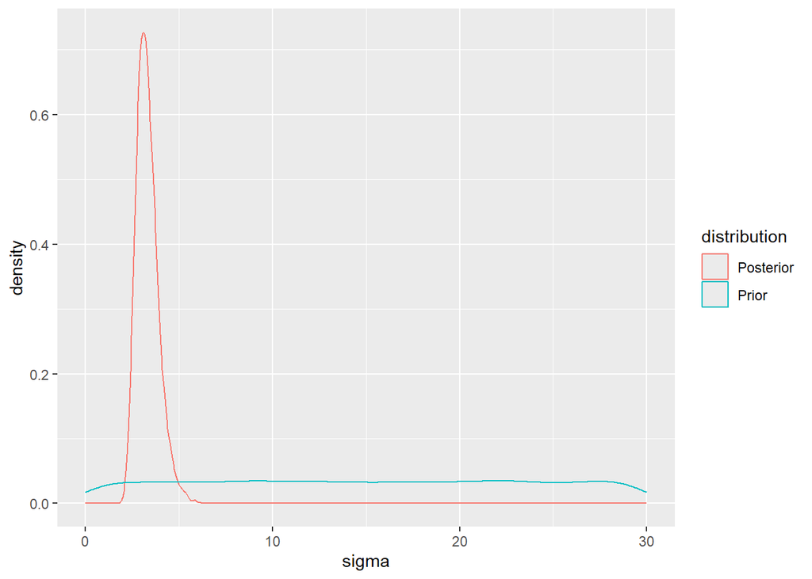

```r
priorpost <- data.frame(sigma = c(MCMCchains(t.test.jags, params="sigma"), Prior.samples),
                        distribution = rep(c("Posterior", "Prior"), each = 15000))

ggplot(priorpost, aes(sigma, col=distribution)) +
   geom_density()
```